# Simulation MixPCR - sans constante

## Lecture des resultats

```r
res.simu = read.table("ResultsSummarySansCste.txt",header=TRUE)
```

## Données manquantes

Pour certaines configurations, l’algorithme ne tourne pas (variances négatives dans les premières itérations).

```r
sum(apply(res.simu,1,anyNA))
```

```
## [1] 19
```

```r
table(apply(res.simu,1,anyNA),as.factor(res.simu$SNR1))
```

```
##
##           3   5  10
##   FALSE 100 500  81
##   TRUE    0   0  19
```

Exclusivement quand SNR1 = 10, soit quand le bruit autour des courbes est faible.

Pour la suite, on retire ces lignes

```r
res.simu = na.omit(res.simu)
```

## Decroissance vraisemblance

```r
sum(res.simu$llik.dec)
```

```
## [1] 678
```

```r
table(as.factor(res.simu$llik.dec),as.factor(res.simu$n))
```

```
##
##     500 1000 10000
##   0   0    3     0
##   1 100  478   100
```

## estimation taille des groupes

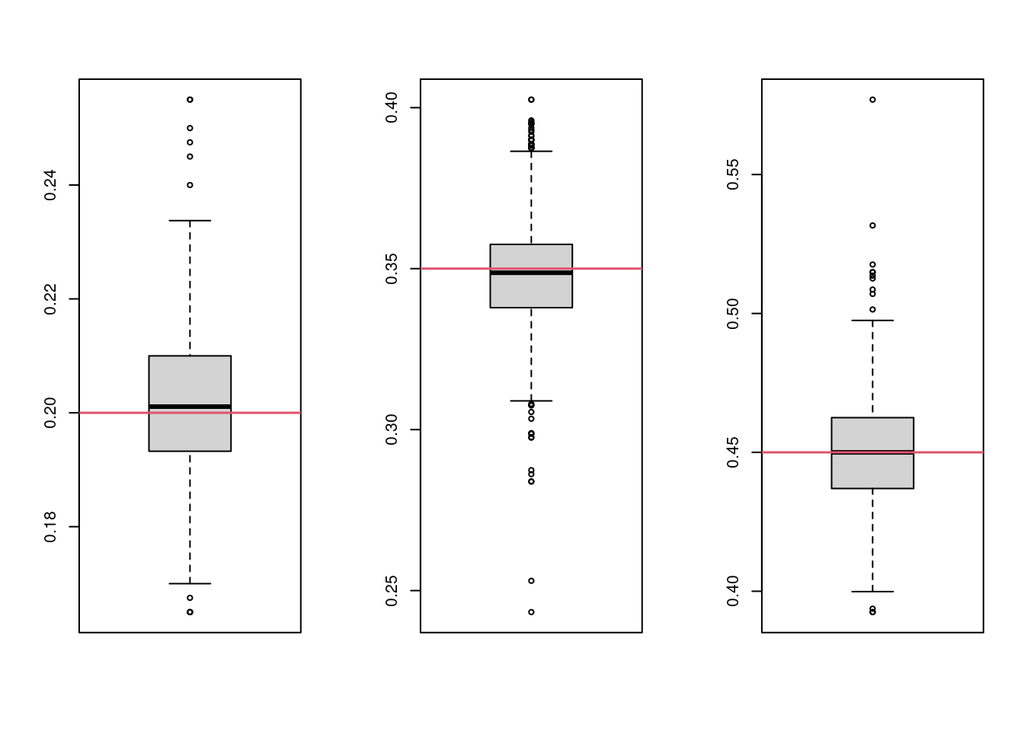

```r
par(mfrow=c(1,3))
for (k in 1:3){
  summary(res.simu[,5+k])
  boxplot(res.simu[,5+k])
  abline(h=pii[k],lwd=1.5,col=2)
}
```

On observe qu’on retrouve assez bien les tailles de groupes, en tout cas, en moyenne. A regarder en fonction de `n` et des SNR.

## estimation theta2

On calcule le MSE par rapport au theta2 réel

```r
RelMSE.theta2 = (res.simu$theta2.hat-res.simu$theta2.sim)/res.simu$theta2.sim
MSE.theta2 = (res.simu$theta2.hat-res.simu$theta2.sim)^2
```

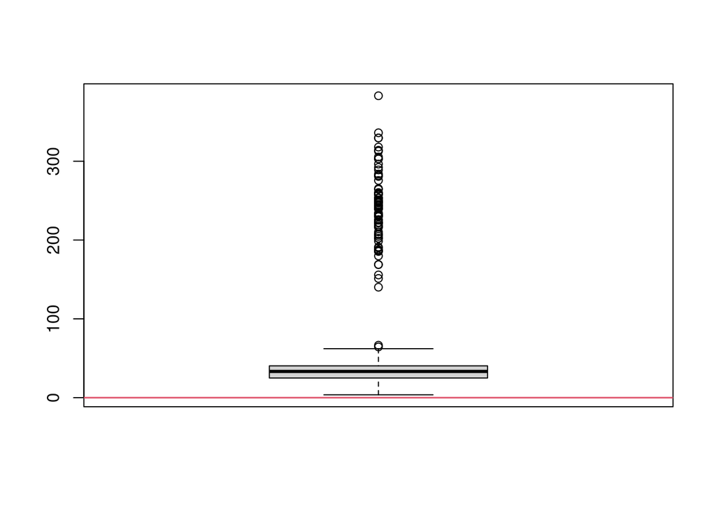

```r
boxplot(RelMSE.theta2)
abline(h=0,lwd=1.5,col=2)
```

L’erreur relative estimée est grande et toujours positive, on surestime ce paramètre dans nos simulations.

- En fonction de `n`

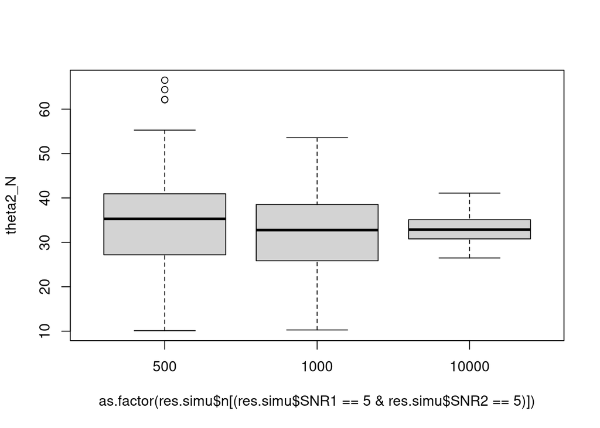

```r
theta2_N = RelMSE.theta2[(res.simu$SNR1==5 & res.simu$SNR2==5)]
boxplot(theta2_N~as.factor(res.simu$n[(res.simu$SNR1==5 & res.simu$SNR2==5)]))
```

Les variabilités pour n=500 et n=10000 semblent contrôlées et on a bien une diminution de la variabilité lorsque n augmente.

```r
aggregate(theta2_N,by=list(as.factor(res.simu$n[(res.simu$SNR1==5 & res.simu$SNR2==5)])),mean)
```

| Group.1 | x |
| --- | --- |
| 500 | 34.65397 |
| 1000 | 32.14275 |
| 10000 | 32.92988 |

- En fonction de SNR1

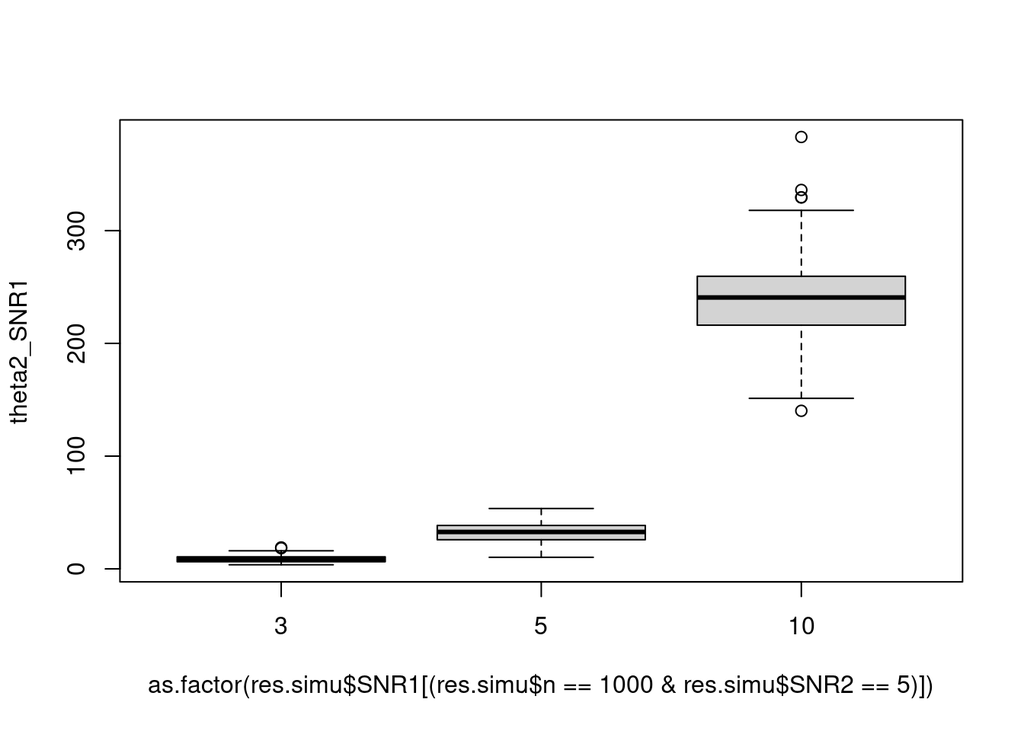

```r
theta2_SNR1 = RelMSE.theta2[(res.simu$n==1000 & res.simu$SNR2==5)]
boxplot(theta2_SNR1~as.factor(res.simu$SNR1[(res.simu$n==1000 & res.simu$SNR2==5)]))
```

Quand SNR1 augmente (le bruit diminue), l’erreur sur theta 2 augmente aussi

- En fonction de SNR2

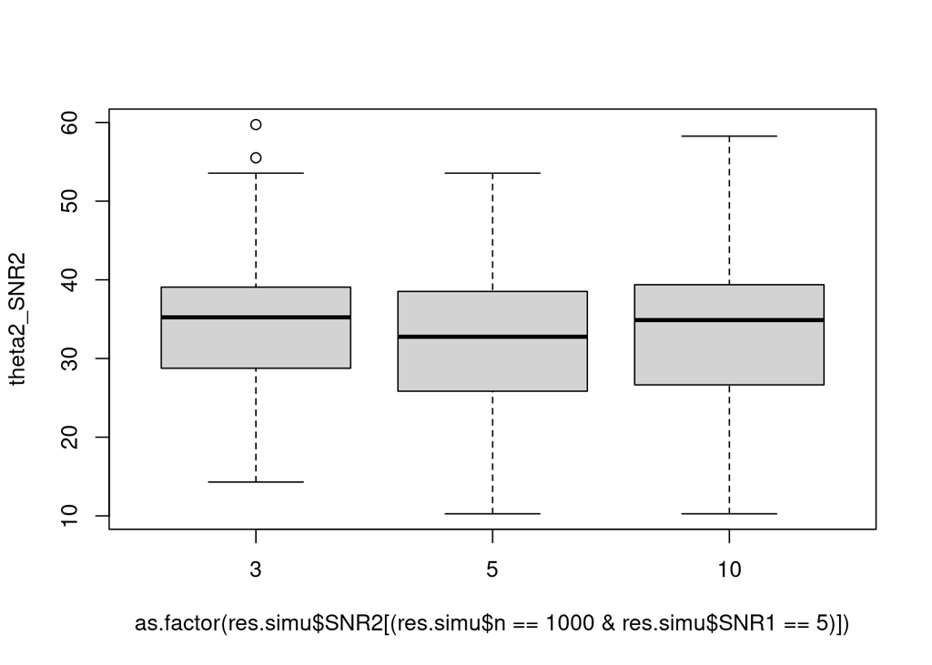

```r
theta2_SNR2 = RelMSE.theta2[(res.simu$n==1000 & res.simu$SNR1==5)]
boxplot(theta2_SNR2~as.factor(res.simu$SNR2[(res.simu$n==1000 & res.simu$SNR1==5)]))
```

Le résultat est différent pour SNR2, ses valeurs ne semblent pas influer autant sur theta2 (un peu bizarre, theta2 est déterminé à partir de SNR2…).

```r
mean(MSE.theta2)
```

```
## [1] 4.935275
```

```r
sd(MSE.theta2)
```

```
## [1] 3.911287
```

Indicateurs pour les MSE absolus, plus difficile à interpréter.

## Estimation sigma2

Idem, on calcule l’erreur relative (signée)

```r
RelMSE.sigma2 = ((res.simu$sigma2.hat-res.simu$sigma2.sim)/res.simu$sigma2.sim)
MSE.sigma2 = (res.simu$sigma2.hat-res.simu$sigma2.sim)^2
```

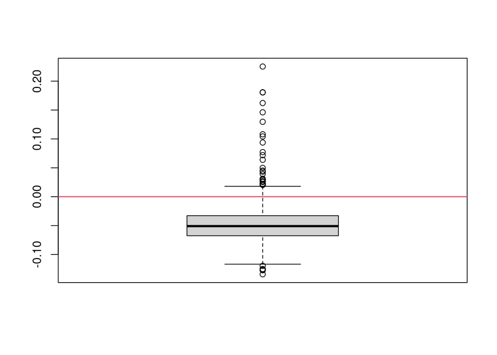

```r
boxplot(RelMSE.sigma2)
abline(h=0,lwd=1.5,col=2)
```

L’erreur relative reste faible sur ce paramètre, on a plutôt tendance à le sous-estimer dans les simulations.

```r
mean(MSE.sigma2)
```

```
## [1] 5.150695e-06
```

```r
sd(MSE.sigma2)
```

```
## [1] 5.595693e-06
```

- En fonction de `n`

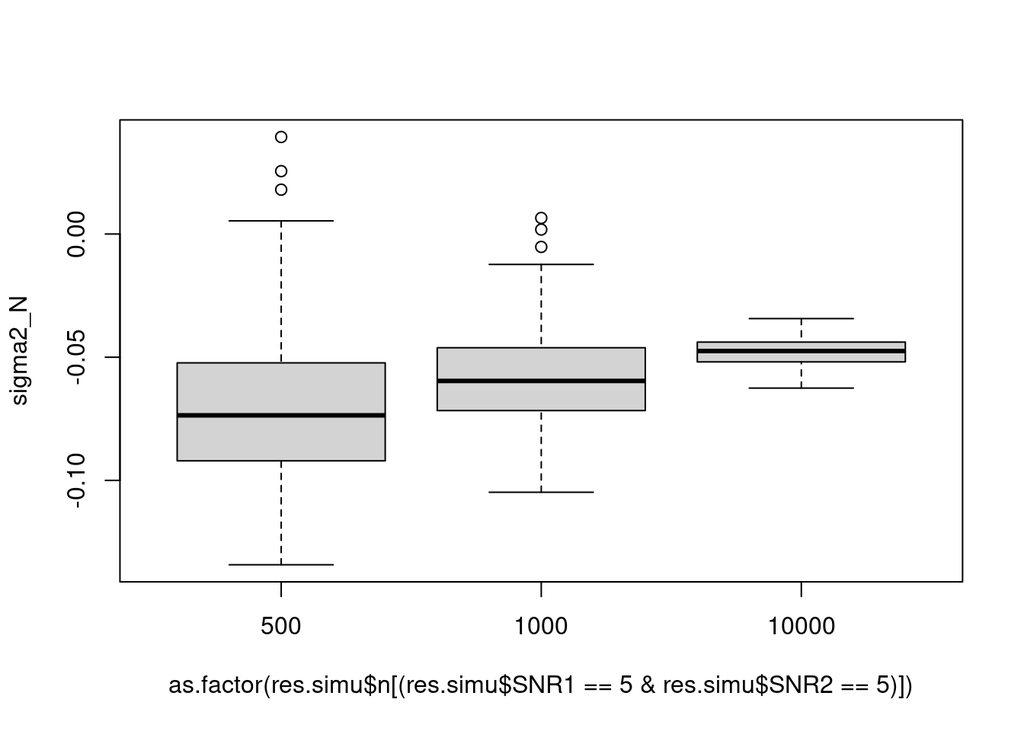

```r
sigma2_N = RelMSE.sigma2[(res.simu$SNR1==5 & res.simu$SNR2==5)]
boxplot(sigma2_N~as.factor(res.simu$n[(res.simu$SNR1==5 & res.simu$SNR2==5)]))
```

La variabilité diminue avec n et l’erreur aussi (erreur relative négative) : semble cohérent

- En fonction de SNR1

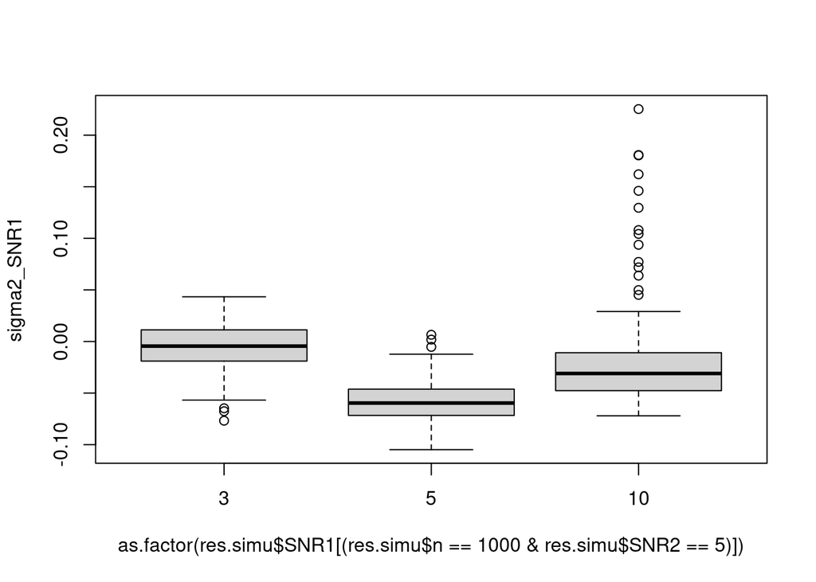

```r
sigma2_SNR1 = RelMSE.sigma2[(res.simu$n==1000 & res.simu$SNR2==5)]
boxplot(sigma2_SNR1~as.factor(res.simu$SNR1[(res.simu$n==1000 & res.simu$SNR2==5)]))
```

Moins clair pour le SNR1, l’erreur augmente légérement (peu significatif)

- En fonction de SNR2

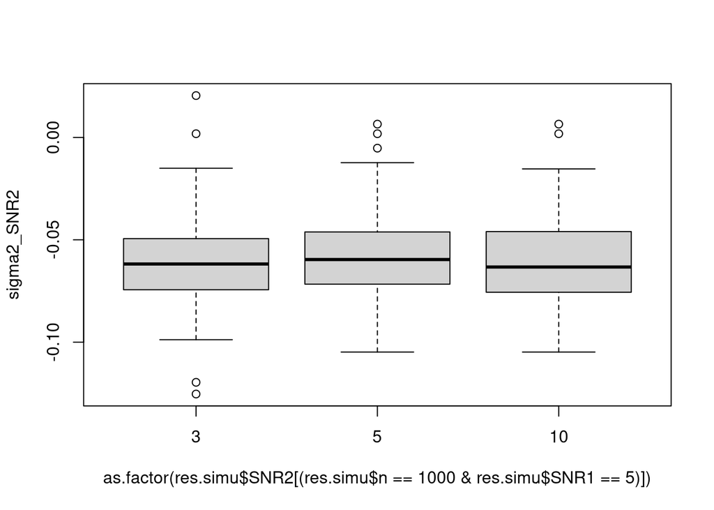

```r
sigma2_SNR2 = RelMSE.sigma2[(res.simu$n==1000 & res.simu$SNR1==5)]
boxplot(sigma2_SNR2~as.factor(res.simu$SNR2[(res.simu$n==1000 & res.simu$SNR1==5)]))
```

Pas d’effet concluant ce qui est moins surprenant car sigma2 est déterminé à partir de SNR1

## Estimation Q, beta et leur produit (identifiabilité)

Q et beta sont des matrices, l’indicateur calculé ici, en première intention, est un indicateur global moyenné sur toutes les composantes.

- Globalement

Pour les matrices Qk par groupe

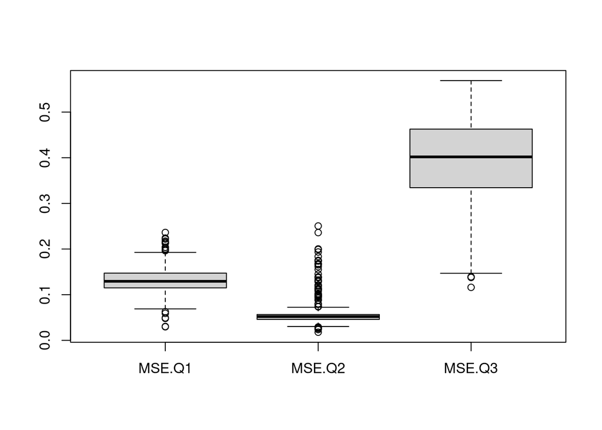

```r
boxplot(res.simu[,16:18])
```

Pour les matrices betak par groupe

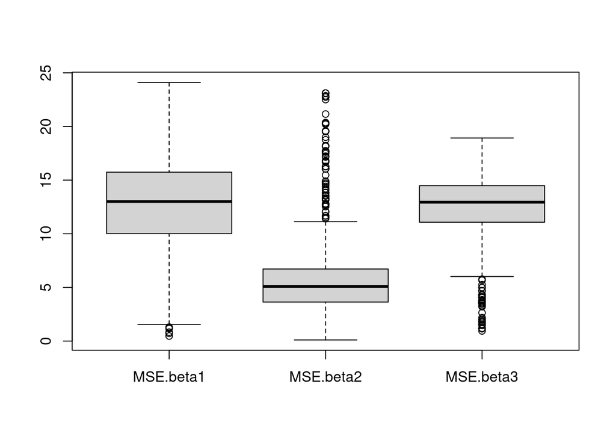

```r
boxplot(res.simu[,19:21])
```

Il semble y avoir des effets de groupe identiques pour Q et beta : étudier d’où ça peut venir

Pour le produit par groupe

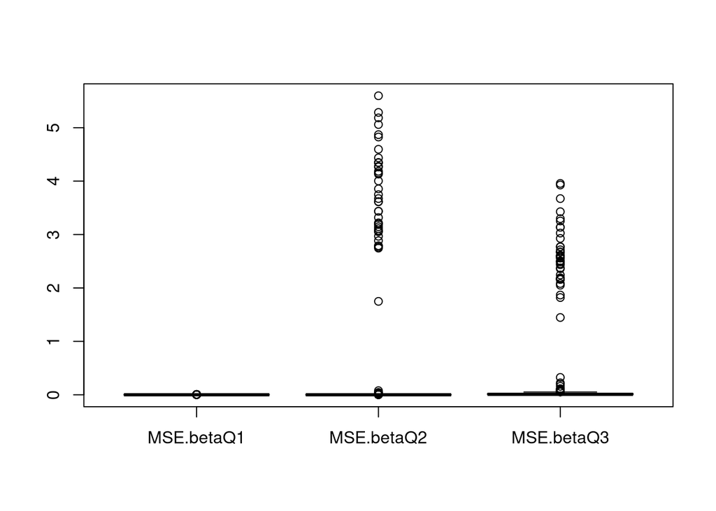

```r
boxplot(res.simu[,22:24])
```

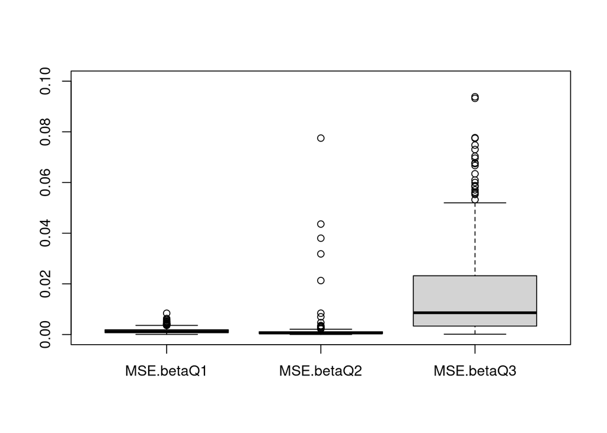

```r
boxplot(res.simu[,22:24],ylim=c(0,0.1))
```

Au delà de quelques outliers, le produit est globalement très bien estimé. En tout cas, mieux que chacun des paramètres séparément. Le fait d’enlever la constante ne résoud pas le problème de l’identifiabilité.

- En fonction de n

```r
res.simu_N = res.simu[(res.simu$SNR1==5 & res.simu$SNR2==5),]
```

Pour les matrices Qk par groupe

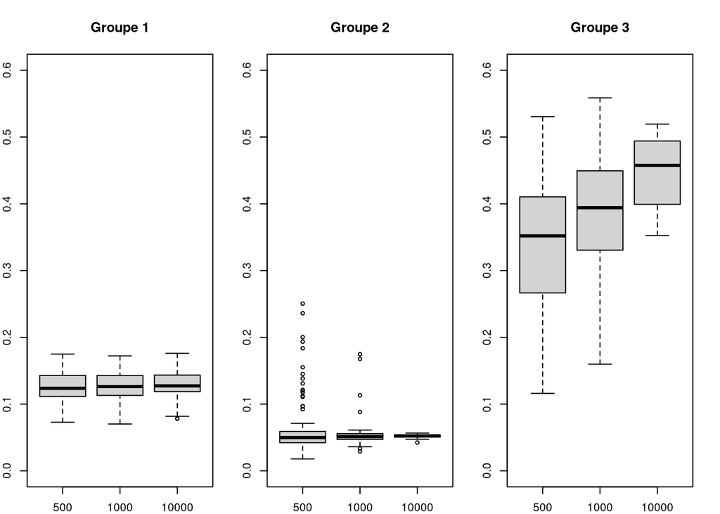

```r
par(mfrow=c(1,3))
par(mar=c(2,2,4,2))
boxplot(res.simu_N[,16]~as.factor(res.simu_N$n),main="Groupe 1",ylim=c(0,0.6))
boxplot(res.simu_N[,17]~as.factor(res.simu_N$n),main="Groupe 2",ylim=c(0,0.6))
boxplot(res.simu_N[,18]~as.factor(res.simu_N$n),main="Groupe 3",ylim=c(0,0.6))
```

Pour les matrices betak par groupe

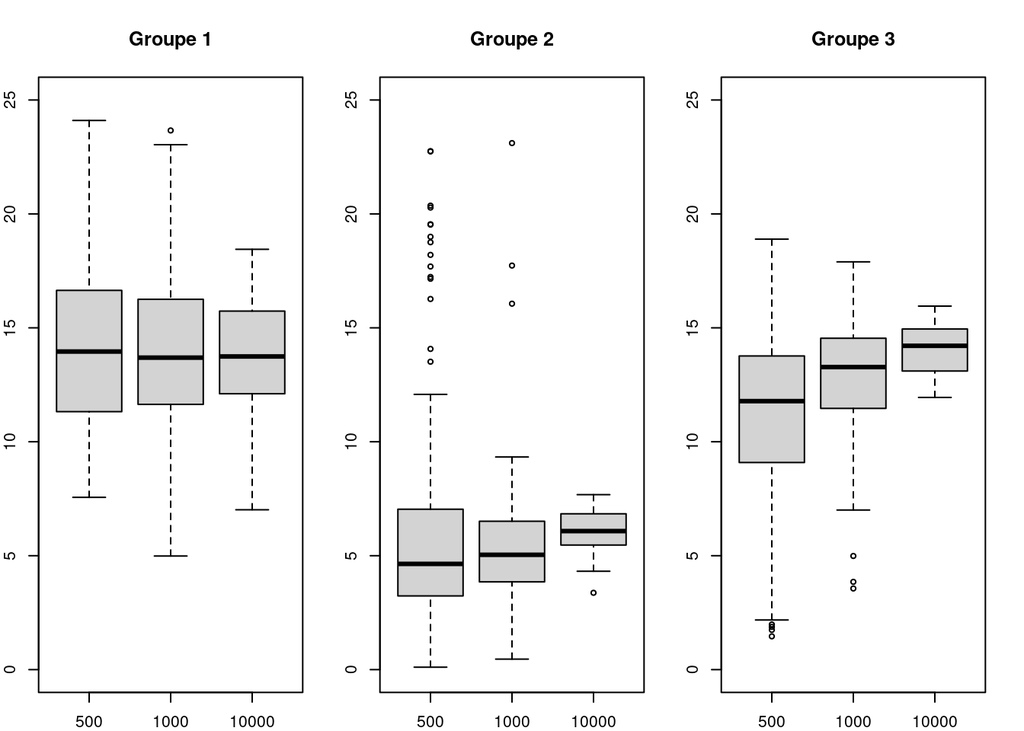

```r
par(mfrow=c(1,3))
par(mar=c(2,2,4,2))
boxplot(res.simu_N[,19]~as.factor(res.simu_N$n),main="Groupe 1",ylim=c(0,25))
boxplot(res.simu_N[,20]~as.factor(res.simu_N$n),main="Groupe 2",ylim=c(0,25))
boxplot(res.simu_N[,21]~as.factor(res.simu_N$n),main="Groupe 3",ylim=c(0,25))
```

Pour le produit par groupe

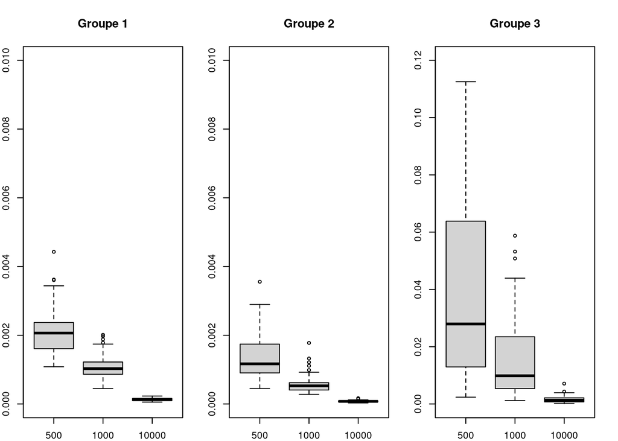

```r
par(mfrow=c(1,3))
par(mar=c(2,2,4,2))
boxplot(res.simu_N[,22]~as.factor(res.simu_N$n),main="Groupe 1",ylim=c(0,0.01))
boxplot(res.simu_N[,23]~as.factor(res.simu_N$n),main="Groupe 2",ylim=c(0,0.01))
boxplot(res.simu_N[,24]~as.factor(res.simu_N$n),main="Groupe 3",ylim=c(0,0.12))
```

- En fonction de SNR1

```r
res.simu_SNR1 = res.simu[(res.simu$n==1000 & res.simu$SNR2==5),]
```

Pour les matrices Qk par groupe

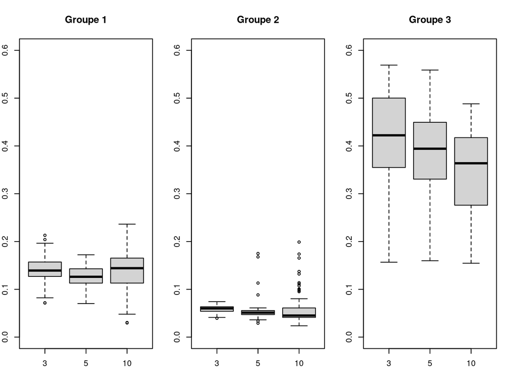

```r
par(mfrow=c(1,3))
par(mar=c(2,2,4,2))
boxplot(res.simu_SNR1[,16]~as.factor(res.simu_SNR1$SNR1),main="Groupe 1",ylim=c(0,0.6))
boxplot(res.simu_SNR1[,17]~as.factor(res.simu_SNR1$SNR1),main="Groupe 2",ylim=c(0,0.6))
boxplot(res.simu_SNR1[,18]~as.factor(res.simu_SNR1$SNR1),main="Groupe 3",ylim=c(0,0.6))
```

Pour les matrices betak par groupe

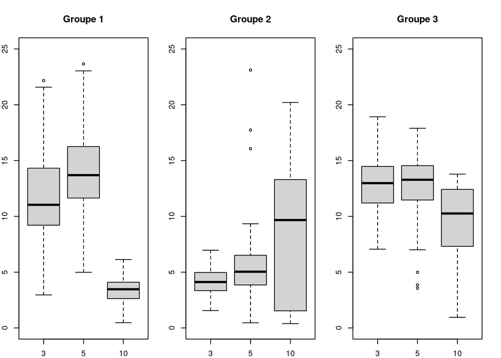

```r
par(mfrow=c(1,3))
par(mar=c(2,2,4,2))
boxplot(res.simu_SNR1[,19]~as.factor(res.simu_SNR1$SNR1),main="Groupe 1",ylim=c(0,25))
boxplot(res.simu_SNR1[,20]~as.factor(res.simu_SNR1$SNR1),main="Groupe 2",ylim=c(0,25))
boxplot(res.simu_SNR1[,21]~as.factor(res.simu_SNR1$SNR1),main="Groupe 3",ylim=c(0,25))
```

Pour le produit par groupe

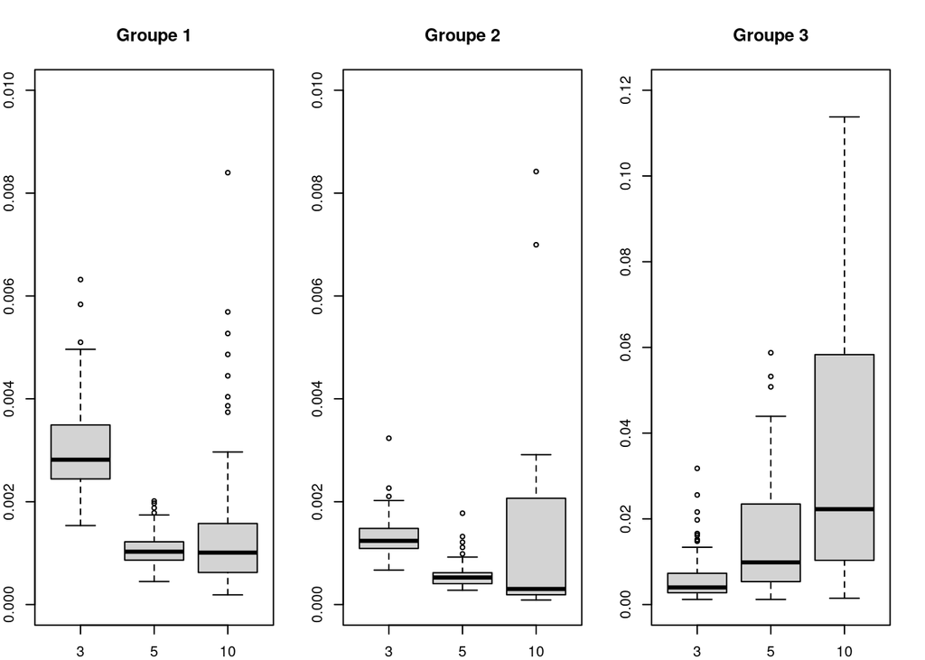

```r
par(mfrow=c(1,3))
par(mar=c(2,2,4,2))
boxplot(res.simu_SNR1[,22]~as.factor(res.simu_SNR1$SNR1),main="Groupe 1",ylim=c(0,0.01))
boxplot(res.simu_SNR1[,23]~as.factor(res.simu_SNR1$SNR1),main="Groupe 2",ylim=c(0,0.01))
boxplot(res.simu_SNR1[,24]~as.factor(res.simu_SNR1$SNR1),main="Groupe 3",ylim=c(0,0.12))
```

- En fonction de SNR2

```r
res.simu_SNR2 = res.simu[(res.simu$n==1000 & res.simu$SNR1==5),]
```

Pour les matrices Qk par groupe

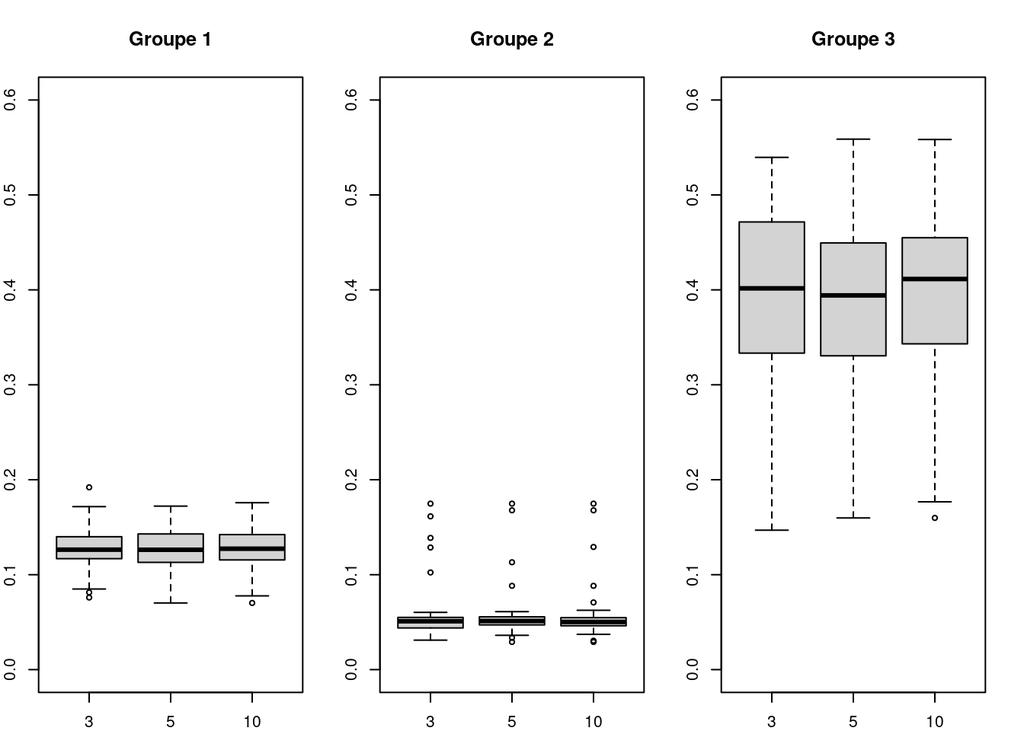

```r
par(mfrow=c(1,3))
par(mar=c(2,2,4,2))
boxplot(res.simu_SNR2[,16]~as.factor(res.simu_SNR2$SNR2),main="Groupe 1",ylim=c(0,0.6))
boxplot(res.simu_SNR2[,17]~as.factor(res.simu_SNR2$SNR2),main="Groupe 2",ylim=c(0,0.6))
boxplot(res.simu_SNR2[,18]~as.factor(res.simu_SNR2$SNR2),main="Groupe 3",ylim=c(0,0.6))
```

Pour les matrices betak par groupe

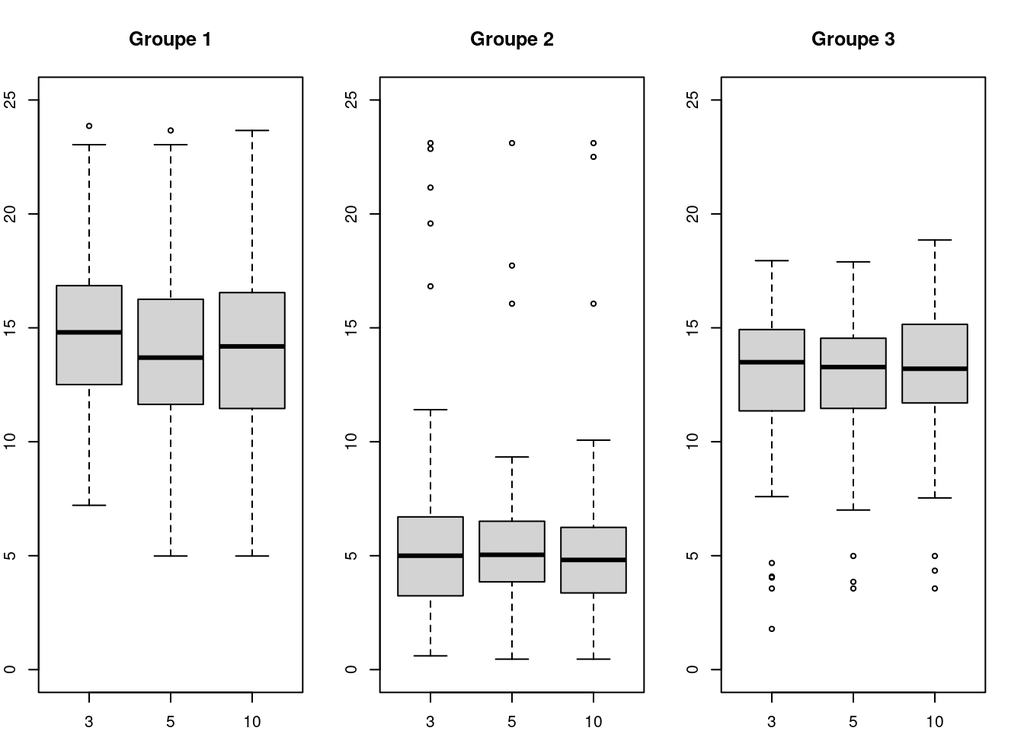

```r
par(mfrow=c(1,3))
par(mar=c(2,2,4,2))
boxplot(res.simu_SNR2[,19]~as.factor(res.simu_SNR2$SNR2),main="Groupe 1",ylim=c(0,25))
boxplot(res.simu_SNR2[,20]~as.factor(res.simu_SNR2$SNR2),main="Groupe 2",ylim=c(0,25))
boxplot(res.simu_SNR2[,21]~as.factor(res.simu_SNR2$SNR2),main="Groupe 3",ylim=c(0,25))
```

Pour le produit par groupe

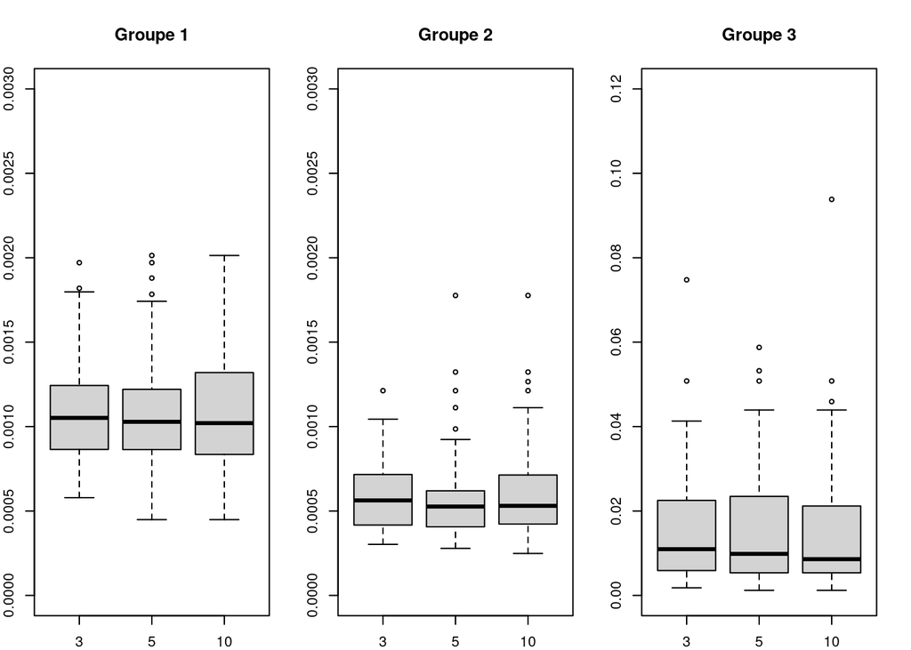

```r
par(mfrow=c(1,3))
par(mar=c(2,2,4,2))
boxplot(res.simu_SNR2[,22]~as.factor(res.simu_SNR2$SNR2),main="Groupe 1",ylim=c(0,0.003))
boxplot(res.simu_SNR2[,23]~as.factor(res.simu_SNR2$SNR2),main="Groupe 2",ylim=c(0,0.003))
boxplot(res.simu_SNR2[,24]~as.factor(res.simu_SNR2$SNR2),main="Groupe 3",ylim=c(0,0.12))
```

## Estimation moyennes mu

Similairement, on calcule un indicateur MSE global dans un premier temps

- Globalement

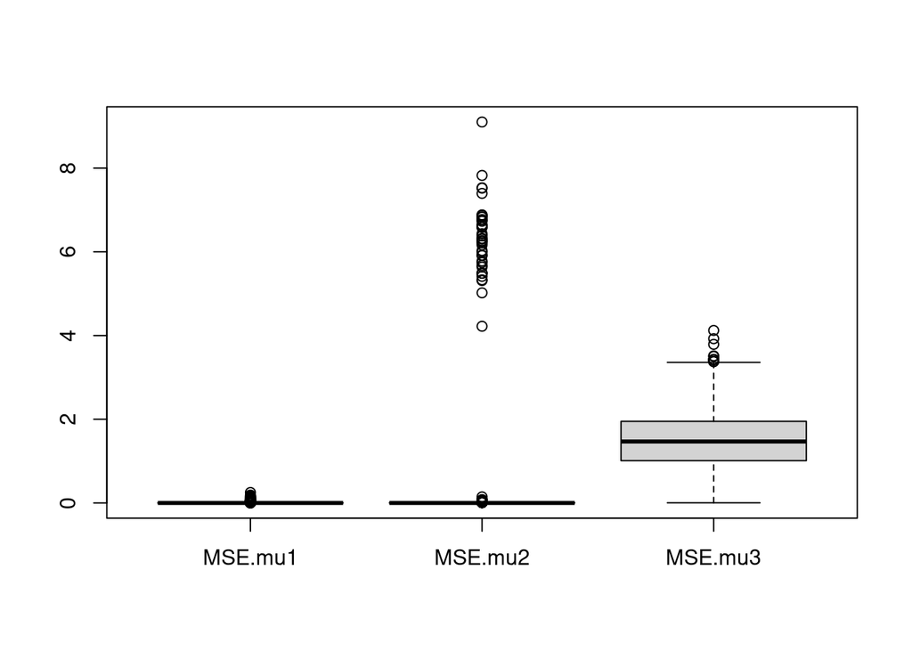

```r
boxplot(res.simu[,13:15])
```

Encore une fois, le troisième groupe semble être plus difficile à estimer

- En fonction de n

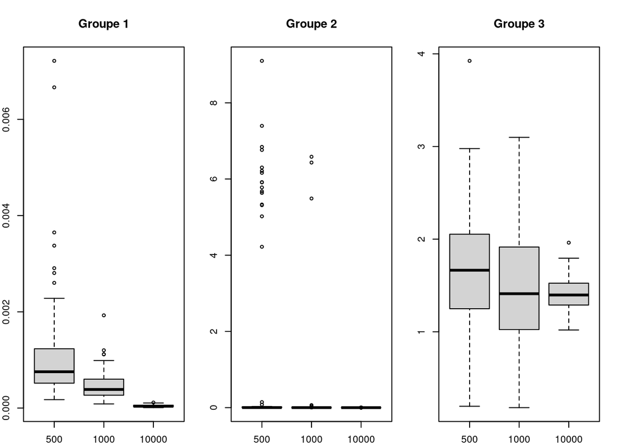

```r
par(mfrow=c(1,3))
par(mar=c(2,2,4,2))
boxplot(res.simu_N[,13]~as.factor(res.simu_N$n),main="Groupe 1")
boxplot(res.simu_N[,14]~as.factor(res.simu_N$n),main="Groupe 2")
boxplot(res.simu_N[,15]~as.factor(res.simu_N$n),main="Groupe 3")
```

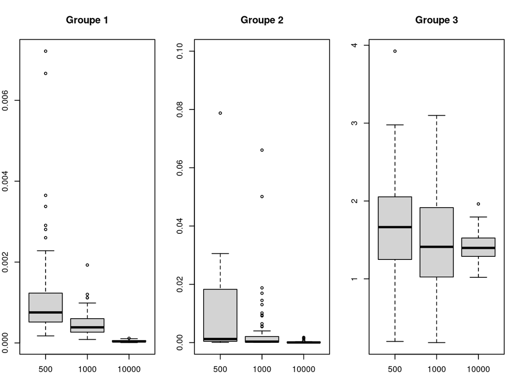

```r
par(mfrow=c(1,3))
par(mar=c(2,2,4,2))
boxplot(res.simu_N[,13]~as.factor(res.simu_N$n),main="Groupe 1")
boxplot(res.simu_N[,14]~as.factor(res.simu_N$n),main="Groupe 2",ylim=c(0,0.1))
boxplot(res.simu_N[,15]~as.factor(res.simu_N$n),main="Groupe 3")
```

- En fonction de SNR1

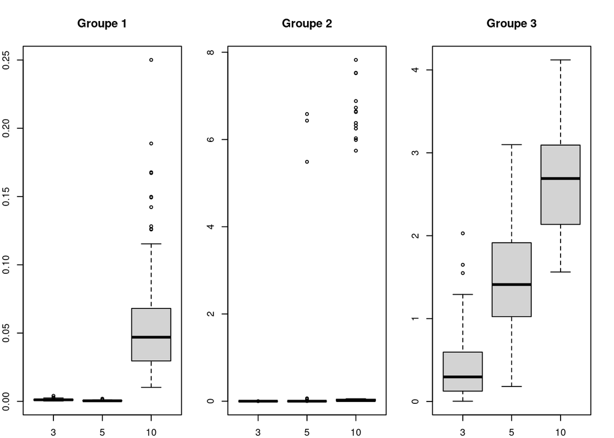

```r
par(mfrow=c(1,3))
par(mar=c(2,2,4,2))
boxplot(res.simu_SNR1[,13]~as.factor(res.simu_SNR1$SNR1),main="Groupe 1")
boxplot(res.simu_SNR1[,14]~as.factor(res.simu_SNR1$SNR1),main="Groupe 2")
boxplot(res.simu_SNR1[,15]~as.factor(res.simu_SNR1$SNR1),main="Groupe 3")
```

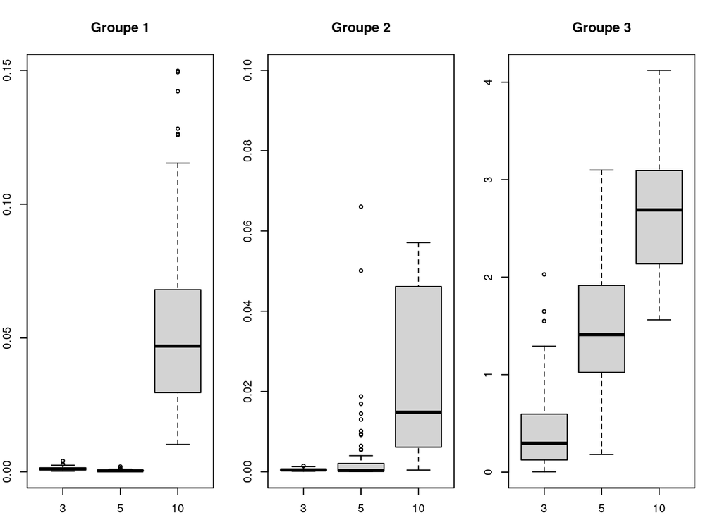

```r
par(mfrow=c(1,3))
par(mar=c(2,2,4,2))
boxplot(res.simu_SNR1[,13]~as.factor(res.simu_SNR1$SNR1),main="Groupe 1",ylim=c(0,0.15))
boxplot(res.simu_SNR1[,14]~as.factor(res.simu_SNR1$SNR1),main="Groupe 2",ylim=c(0,0.1))
boxplot(res.simu_SNR1[,15]~as.factor(res.simu_SNR1$SNR1),main="Groupe 3")
```

Ne va pas dans le bon sens, le MSE est sensé diminuer quand SNR augmente

- En fonction de SNR2

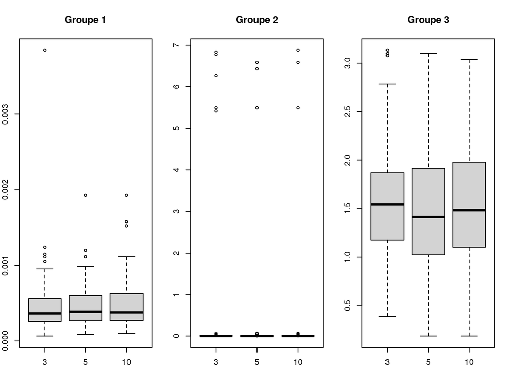

```r
par(mfrow=c(1,3))
par(mar=c(2,2,4,2))
boxplot(res.simu_SNR2[,13]~as.factor(res.simu_SNR2$SNR2),main="Groupe 1")
boxplot(res.simu_SNR2[,14]~as.factor(res.simu_SNR2$SNR2),main="Groupe 2")
boxplot(res.simu_SNR2[,15]~as.factor(res.simu_SNR2$SNR2),main="Groupe 3")
```

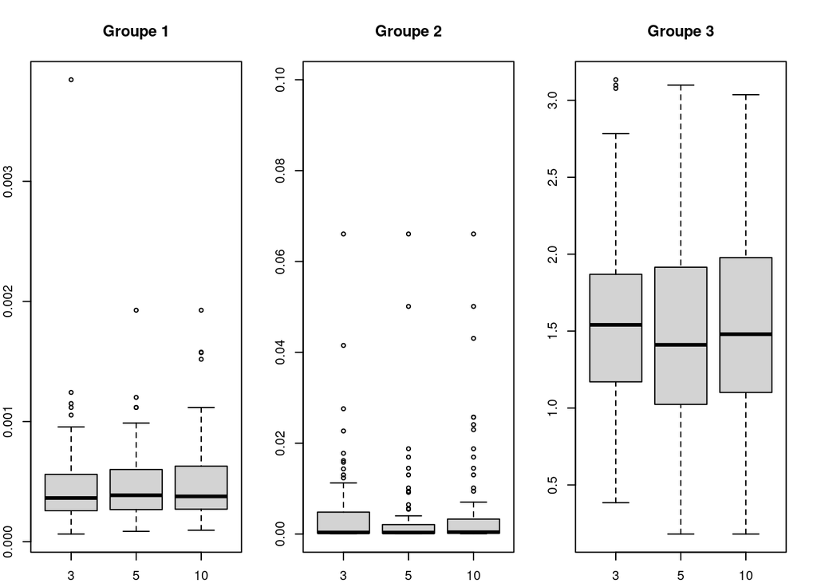

```r
par(mfrow=c(1,3))
par(mar=c(2,2,4,2))
boxplot(res.simu_SNR2[,13]~as.factor(res.simu_SNR2$SNR2),main="Groupe 1")
boxplot(res.simu_SNR2[,14]~as.factor(res.simu_SNR2$SNR2),main="Groupe 2",ylim=c(0,0.1))
boxplot(res.simu_SNR2[,15]~as.factor(res.simu_SNR2$SNR2),main="Groupe 3")
```

Le groupe 3 se détache clairement (négativement) dans les MSE. C’est assez flagrant sur la moyenne. Pour mémoire, le groupe 3 correspond à une courbe constante, c’est sans doute “plus difficile” à retrouver.